# Question

A polynomial is sketched below.

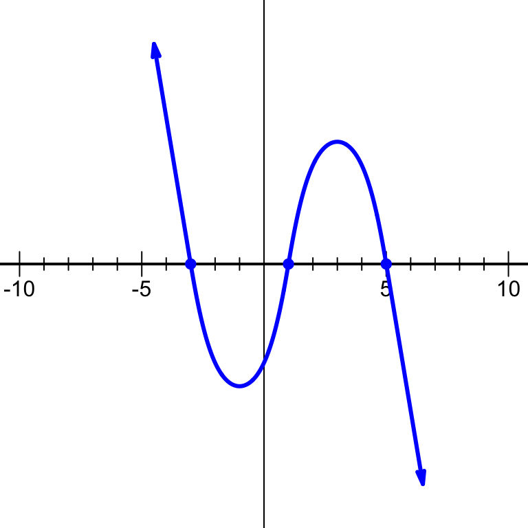

Which polynomial (in factored form) best matches the sketch?

## Answerlist

- $y=(x-1)(x-5)(x+3)$
- $y=(x+1)(x+5)(x-3)$
- $y=-(x-1)(x-5)(x+3)$
- $y=-(x+1)(x+5)(x-3)$

# Solution

If a polynomial has a factor of $(x-r)$, then there will be an $x$-intercept at $(r,0)$.

In this case, the roots (the $x$-intercepts) are at:

$$-3,\,1,\,5$$

Thus, the factors are $x+3$ and $x-1$ and $x-5$. So, we know that the function could be written as:

$$y=a(x+3)(x-1)(x-5)$$

where $a$ is some constant.

Lastly, we need to determine whether $a$ should be positive or negative. In this problem, either $a=1$ or $a=-1$. To determine this, look at the right side of the graph. Specifically, we are considering the [end behavior of polynomials](https://www.khanacademy.org/math/algebra2/x2ec2f6f830c9fb89:poly-graphs/x2ec2f6f830c9fb89:poly-end-behavior/a/end-behavior-of-polynomials). Notice that once $x$ is larger than $5$, all the factors will be positive, so only $a$ will dictate whether the function on the right side is positive or negative.

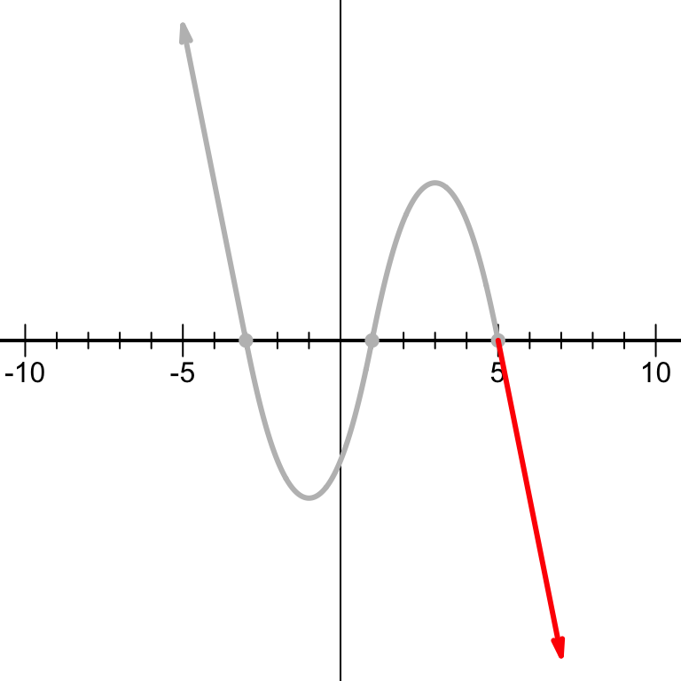

Notice, on the right side, the function is heading down. I guess more importantly, as $x\to \infty$ we see the function is negative. This implies that $a$ is negative. So, in this case, $a=-1$.

$$y=-(x+3)(x-1)(x-5)$$

And then, since multiplication is commutative, the factors can be written in any order. In this case, the correct answer is:

$$y=-(x-1)(x-5)(x+3)$$

# Meta-information

extype: schoice exsolution: 0010 exname: poly_sketch